# INFS3201/7202 Lab 6: Creating CRUD Applications

Welcome to Lab 6. HTML forms are essential in web development because they let users send information back to the server. This capability is key for making websites where users can interact, like in creating, reading, updating, and deleting data - commonly known as CRUD applications. Besides these actions, forms are crucial for user registrations and logins, making them indispensable for any site that offers personalized content or requires user authentication.

This lab focuses on using Django to handle form processing and user logins. Whether you’re building a simple blog or a complex web application, understanding how to process forms is vital.

In this Lab you will extend the Resume Builder application by:

- **Updating the Base Template**: In Lab 4 you designed a new header and footer using Bootstrap 5. In this Lab you will use your design to make a new base template.
- **Implementing the Subscriber Management Panel**: You will implement a full CRUD to Add, Edit and Delete subscribers (users) of the ResumeBuilder SaaS. You will also implement search functionality.

This is what the Manage Subscribers Panel will look like by the end of this Lab:

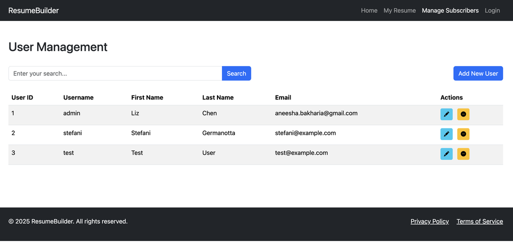

**Note**

We won’t be using the Django Admin panel. In this Lab you will learn to build a full CRUD UI from scratch in Django.

**Note**

You will need to use the Lab 4 HTML Mockups in the Lab. These files were provided in the Lab 4 Solution download. If you created a customized look and feel, please use your own version of the Mockups you created in Lab 4.

**Note**

Simple form processing and saving to a database table (via a Model) examples were covered in the Week 5 Lecture. All code was provided in the Lecture, for your reference.

This Lab is an advanced version that shows how to build a full CRUD to Manage Subscribers.

## Creating a Base Template in Django with Bootstrap

To integrate your Bootstrap design into Django, we’ll split the HTML into two parts:

- A **base template** that includes the common layout (header, footer, styles).
- A **landing page template** that extends the base and adds the homepage content.

To keep your HTML clean and reusable, Django encourages using a **base template** that other pages can extend. This way, you define common elements like headers, footers, styles, and scripts just once.

Here’s how to turn your Bootstrap design into a proper base layout and landing page.

**Step 1: Enable Request Context in Templates**

Django needs access to the current request to highlight the active link in the navbar. In `settings.py`, ensure that `'django.template.context_processors.request'` is added to the `'context_processors'` list:

```python
# settings.py

TEMPLATES = [
    {
        'BACKEND': 'django.template.backends.django.DjangoTemplates',
        'DIRS': [],
        'APP_DIRS': True,
        'OPTIONS': {
            'context_processors': [
                'django.template.context_processors.debug',
                'django.template.context_processors.request',
                'django.contrib.auth.context_processors.auth',
                'django.contrib.messages.context_processors.messages',
                'django.template.context_processors.request',  # Required for navbar highlighting
            ],
        },
    },
]
```

**Step 2: Create the Base Template**

Replace `templates/base.html` with one that now includes our latest design (From the Week 4 Lab). This template includes:

- Header and footer (shared across pages)
- Bootstrap styles and scripts
- `{% block %}` placeholders for page-specific content
- Navbar with dynamic `active` highlighting using `request.resolver_match.url_name`

```html
<!-- templates/base.html -->
<!doctype html>
<html lang="en">
  <head>
    <meta charset="utf-8">
    <meta name="viewport" content="width=device-width, initial-scale=1">
    <title>{% block title %}ResumeBuilder{% endblock %}</title>
    <link href="https://cdn.jsdelivr.net/npm/bootstrap@5.3.3/dist/css/bootstrap.min.css" rel="stylesheet">
    <link rel="stylesheet" href="https://cdn.jsdelivr.net/npm/bootstrap-icons@1.11.3/font/bootstrap-icons.min.css">
  </head>
  <body>
    <!-- Header -->
    <header>
      <nav class="navbar navbar-expand-lg navbar-dark bg-dark">
        <div class="container">
          <a class="navbar-brand" href="{% url 'index' %}">ResumeBuilder</a>
          <button class="navbar-toggler" type="button" data-bs-toggle="collapse" data-bs-target="#navbarNav">
            <span class="navbar-toggler-icon"></span>
          </button>
          <div class="collapse navbar-collapse" id="navbarNav">
            <ul class="navbar-nav ms-auto">
              <li class="nav-item">
                <a class="nav-link {% if request.resolver_match.url_name == 'index' %}active{% endif %}" href="{% url 'index' %}">Home</a>
              </li>
              <li class="nav-item">
                <a class="nav-link {% if request.resolver_match.url_name == 'myresume' %}active{% endif %}" href="{% url 'myresume' %}">My Resume</a>
              </li>
              <li class="nav-item">
                <a class="nav-link {% if request.resolver_match.url_name == 'manage' %}active{% endif %}" href="{% url 'manage' %}">Manage Subscribers</a>
              </li>
              <li class="nav-item">
                <a class="nav-link" href="#">Login</a>
              </li>
            </ul>
          </div>
        </div>
      </nav>
    </header>

    <!-- Main Content -->
    <main>
      {% block content %}{% endblock %}
    </main>

    <!-- Footer -->
    <footer class="bg-dark text-light py-4 mt-5">
      <div class="container">
        <div class="row">
          <div class="col-md-6">
            <p>&copy; {% now "Y" %} ResumeBuilder. All rights reserved.</p>
          </div>
          <div class="col-md-6 text-md-end">
            <a href="#" class="text-light me-3">Privacy Policy</a>
            <a href="#" class="text-light">Terms of Service</a>
          </div>
        </div>
      </div>
    </footer>

    <script src="https://cdn.jsdelivr.net/npm/bootstrap@5.3.3/dist/js/bootstrap.bundle.min.js"></script>
  </body>
</html>
```

**Step 3: Create the Landing Page Template**

Now create a landing page (`templates/landingpage.html`) that extends the base:

```html
{% extends "base.html" %}

{% block title %}Welcome to ResumeBuilder{% endblock %}

{% block content %}
<section class="py-5 bg-light">
  <div class="container">
    <div class="row">
      <div class="col-lg-6">
        <h1 class="display-4">Create Professional Resumes Effortlessly</h1>
        <p class="lead">ResumeBuilder simplifies the process of creating stunning resumes that stand out.</p>
        <a href="#" class="btn btn-primary btn-lg">Get Started</a>
      </div>
      <div class="col-lg-6">
        <img src="resumebuilder.png" alt="ResumeBuilder Screenshot" class="img-fluid rounded shadow">
      </div>
    </div>
  </div>
</section>

<section class="py-5">
  <div class="container">
    <h2 class="text-center mb-4">Key Features</h2>
    <div class="row">
      <div class="col-lg-4 mb-4">
        <div class="card">
          <div class="card-body">
            <h4 class="card-title">Customizable Templates</h4>
            <p class="card-text">Choose from a variety of professionally designed resume templates.</p>
          </div>
        </div>
      </div>
      <div class="col-lg-4 mb-4">
        <div class="card">
          <div class="card-body">
            <h4 class="card-title">Easy-to-Use Interface</h4>
            <p class="card-text">Our intuitive interface makes it simple to create and edit your resume.</p>
          </div>
        </div>
      </div>
      <div class="col-lg-4 mb-4">
        <div class="card">
          <div class="card-body">
            <h4 class="card-title">PDF & Word Downloads</h4>
            <p class="card-text">Easily download your resume in PDF or Word format for sharing.</p>
          </div>
        </div>
      </div>
    </div>
  </div>
</section>
{% endblock %}
```

**Step 4: Create the View for the Landing Page**

In your app’s `views.py` add views for the Landing Page and My Resume nav bar links:

```python
# views.py

from django.http import HttpResponse
from django.shortcuts import render, get_object_or_404
from .models import UserDetail, Qualification, WorkExperience

def index(request):
    return render(request, "landingpage.html")

def myresume(request):
    user_details = get_object_or_404(UserDetail, id=1) # Note a hardcoded user id
    qualifications = Qualification.objects.filter(user=user_details)
    work_experience = WorkExperience.objects.filter(user=user_details)

    context = {
        "name": f"{user_details.firstname} {user_details.surname}",
        "mobileno": user_details.mobileno,
        "qualifications": qualifications,
        "work_experience": work_experience,
    }
    return render(request, "resume.html", context)

def managesubscribers(request):
    return render(request, "manage.html") # This is temporary

def about(request):
    return render(request, "about.html") # This is temporary
```

**Step 5: Wire It Up in `urls.py`**

In your app’s `resumeapp/urls.py`, connect the `index` view to the homepage:

```python
# urls.py

from django.urls import path
from . import views

urlpatterns = [
    path('', views.index, name='index'),  # This makes 'index' available in your template
    path("myresume/", views.myresume, name="myresume"),
    path("about/", views.about, name="about"),
    path("manage/", views.managesubscribers, name="manage"),

]
```

5. **Preview the Landing Page**: Visit https://YourUQZoneURL/resumebuilder to see the new Resume Builder landing page. Resize the browser window. The Nav bar should change to a hamburger menu on smaller screens. The **navbar will highlight** the correct active link based on the page you’re on.

**Note**

You won’t be able to see the image on the landing page. This is because we have not set up static file (e.g. images and js files).

6. **Create Privacy Policy and Terms of Service Pages** (Optional): There are links in the footer to additional pages. Create `paths`, `views` and `templates` for these pages. You can include any content in these pages.

## Setting Up Static Files in Django

Static files are things like CSS, JavaScript, and images that don’t change dynamically. In Django, you need to do a few things to make these files work properly — especially in development.

**Why Django Makes You Do This?**

Django’s default development server (`manage.py runserver`) **isn’t optimized** for serving static files like images or CSS. It’s focused on serving dynamic content (views, templates, models).

To avoid performance issues, Django expects you to **explicitly set up** static file handling using your Webserver (i.e. Nginx), especially when you move to production.

**Step 1. Create a `static/` Folder**

In your app (e.g., `resumeapp/`), create a folder called `static/`, then inside it, create another `resumeapp/` and then add subfolders for organizing your images, javascript and styles. Place the `resumebuilder.png` file inside the images folder.

```
resumeapp/
├── static/
│   └── resumeapp/
│       └── images/
│           └── resumebuilder.png
```

> Tip: Use your app’s name (`resumeapp/`) inside the `static/` folder to prevent file name clashes across apps.

**Step 2. Create a static files folder**

**Step 3. Configure `settings.py`**

Update the `STATIC_URL` path and add `STATIC_ROOT`:

```python
# settings.py

STATIC_URL = 'resumebuilder_static/'

# The directory where collectstatic will place all static files
STATIC_ROOT = "/var/www/htdocs/resumebuilder_static/"  # This is within the Nginx web root folder
```

**Step 4. Use `collectstatic` in Production**

When deploying, Django won’t look in each app’s `static/` folder. Instead, you need to **collect** all static files into one place:

```bash
python3.12 manage.py collectstatic
```

This puts everything into the `STATIC_ROOT` directory, which we are serving using the Nginx webserver.

**Step 5. Load Static Files in Templates**

Now you can link to the any static file in a HTML template.

Add `{% load static %}` below the `{% extends "base.html" %}` tag in the `templates/landingpage.html` template.

```html
{% extends "base.html" %}
{% load static %}
```

Then add `{% static 'resumeapp/images/resumebuilder.png' %}` to the src of the image HTML tag:

```html
<img src="{% static 'resumeapp/images/resumebuilder.png' %}" alt="ResumeBuilder Screenshot" class="img-fluid rounded shadow">
```

**Note**

`{% load static %}` in templates that inherit from the `base` template must be added below the `{% extends "base.html" %}` tag.

**Why All These Steps?**

Django keeps static files separate from your Python code and templates to:

- Avoid accidental serving of sensitive files
- Make it easy to compress, cache, and version files in production
- Keep your dev server fast and clean

While it may seem like a lot at first, it’s a powerful system once you get used to it.

## Implement the Manage Subscribers Panel

The Subscriber Management Panel is a crucial component of your Resume Builder application, offering administrative control for user management. This functionality not only enhances the application’s usability for administrators but also ensures that user data can be effectively managed, including adding new users, editing existing users, and deleting users as necessary. In this section, we’ll update the list view created in Lab 3 to integrate with the new base template and introduce buttons for user management actions.

We’ll use the following tools:

- Django **Class-Based Views** (`ListView`, `CreateView`, `UpdateView`, `DeleteView`)
- Bootstrap layout
- Django **pagination**
- **Search** across `username`, `firstname`, and `surname`

This example showcases how to **extend Django’s class-based views** to handle more complex data entry scenarios—specifically when working with **related models**. This goes further than the content presented in the Lecture. In this case, subscriber information is split across two tables: the built-in `User` model (which holds login credentials and email) and a custom `UserDetail` model (which stores extra profile fields like first name, surname, and mobile number). By customizing the form and view logic, we combine fields from both models into a **single form**, allowing users to add or edit all relevant information at once. This is a common pattern in Django projects where you want a unified user experience but maintain clean, normalized data structures behind the scenes.

This tutorial walks you through creating a CRUD interface to manage subscribers in Django. Each subscriber consists of:

- A Django `User` (username, password, email)
- A `UserDetail` profile (first name, surname, mobile number)

**Step 1: Review Your Models**

We assume you already have a `UserDetail` model with a `OneToOneField` to Django’s built-in `User`:

```python
# models.py

from django.db import models
from django.contrib.auth.models import User

class UserDetail(models.Model):
    user = models.OneToOneField(User, on_delete=models.CASCADE)
    firstname = models.CharField(max_length=100)
    surname = models.CharField(max_length=100)
    mobileno = models.CharField(max_length=15)

    def __str__(self):
        return f"{self.firstname} {self.surname}"
```

Add the following line to your `settings.py` file, if you have not already done so:

```bash
CSRF_TRUSTED_ORIGINS = ["https://yourzoneid.uqcloud.net", "https://infs3202-yourzoneid.uqcloud.net"]
```

This setting tells Django to trust these specific domains when handling secure (HTTPS) POST requests. Without it, Django might block valid requests—especially in cloud-hosted environments like UQCloud—thinking they’re potential CSRF attacks.

**Step 2: Update URL Patterns**

Add paths for 4 class based views that will allow us to view a list, add, edit and delete users to the `resumeapp/urls.py` file.

```python
# urls.py

from django.urls import path
from .views import (
    ManageSubscribersView,
    SubscriberCreateView,
    SubscriberUpdateView,
    SubscriberDeleteView,
)

urlpatterns = [
    path('', views.index, name='index'),  # This makes 'index' available in your template
    path("myresume/", views.myresume, name="myresume"),
    path("about/", views.about, name="about"),
    path("manage/", ManageSubscribersView.as_view(), name="manage"),
    path("manage/add/", SubscriberCreateView.as_view(), name="subscriber_add"),
    path("manage/edit/<int:pk>/", SubscriberUpdateView.as_view(), name="subscriber_edit"),
    path("manage/delete/<int:pk>/", SubscriberDeleteView.as_view(), name="subscriber_delete"),
]
```

**Step 3: Create a Custom Form**

We’ll build a single form that captures both `User` and `UserDetail` info, including setting the password. Add the following code to `resumeapp/forms.py`

```python
# forms.py

from django import forms
from django.contrib.auth.models import User
from .models import UserDetail

class UserDetailFullForm(forms.ModelForm):
    username = forms.CharField(max_length=150, required=True, widget=forms.TextInput(attrs={'class': 'form-control'}))
    password = forms.CharField(widget=forms.PasswordInput(attrs={'class': 'form-control'}))
    email = forms.EmailField(required=True, widget=forms.EmailInput(attrs={'class': 'form-control'}))

    class Meta:
        model = UserDetail
        fields = ['firstname', 'surname', 'mobileno']
        widgets = {
            'firstname': forms.TextInput(attrs={'class': 'form-control'}),
            'surname': forms.TextInput(attrs={'class': 'form-control'}),
            'mobileno': forms.TextInput(attrs={'class': 'form-control'}),
        }

    def save(self, commit=True):
        # Extract the user-related fields
        username = self.cleaned_data.pop("username")
        password = self.cleaned_data.pop("password")
        email = self.cleaned_data.pop("email")

        # Create the user
        user = User.objects.create_user(username=username, password=password, email=email)

        # Create the user detail object
        user_detail = super().save(commit=False)
        user_detail.user = user

        if commit:
            user_detail.save()

        return user_detail
```

This will automatically generate a form with Bootstrap styles for all fields.

**Note**

In your `UserDetailForm` class, the `Meta` class is a special **inner class** that provides metadata to the `ModelForm`. Django uses this information to know how to build the form. Here’s a breakdown of what each part inside `Meta` is doing:

**Tip**

`fields = [...]` Specifies which model fields should be included in the form. Only the fields listed here will appear on the form:

This makes your form look nice and styled with Bootstrap classes.

**Step 4: Create the Views (Class-Based)**

Update your `views.py` to include the new Class-based views to Manage a subscriber. All the code is commented. Please read it carefully and understand what it is doing?

```python
# views.py

from django.http import HttpResponse
from django.shortcuts import render, get_object_or_404
from .models import UserDetail, Qualification, WorkExperience
from django.views.generic import ListView, CreateView, UpdateView, DeleteView
from django.urls import reverse_lazy
from django.contrib import messages
from django.db.models import Q
from .forms import UserDetailFullForm

def index(request):
    return render(request, "landingpage.html")

def myresume(request):
    user_details = get_object_or_404(UserDetail, id=1) # Note a hardcoded user id
    qualifications = Qualification.objects.filter(user=user_details)
    work_experience = WorkExperience.objects.filter(user=user_details)

    context = {
        "name": f"{user_details.firstname} {user_details.surname}",
        "mobileno": user_details.mobileno,
        "qualifications": qualifications,
        "work_experience": work_experience,
    }
    return render(request, "resume.html", context)

def about(request):
    return render(request, "about.html")

# A class-based view to manage and display a paginated list of subscribers
class ManageSubscribersView(ListView):
    model = UserDetail  # This view operates on the UserDetail model
    template_name = "manage_subscribers.html"  # Template to render the list
    context_object_name = "users"  # Context variable name for the list in the template
    paginate_by = 5  # Number of users to display per page

    # Custom queryset to enable search functionality
    def get_queryset(self):
        # Use select_related to optimize DB queries by joining related User table
        queryset = super().get_queryset().select_related("user")

        # Get the search term from the query parameters (?search=...)
        search_query = self.request.GET.get("search", "")

        # If there's a search query, filter the queryset
        if search_query:
            queryset = queryset.filter(
                Q(user__username__icontains=search_query) |  # Match username
                Q(firstname__icontains=search_query) |       # Match first name
                Q(surname__icontains=search_query)           # Match surname
            )

        return queryset  # Return the final filtered or unfiltered queryset


# A class-based view for creating a new subscriber entry
class SubscriberCreateView(CreateView):
    model = UserDetail  # The model that will be created in this form view
    form_class = UserDetailFullForm  # Custom form that likely includes both User and UserDetail fields
    template_name = "subscriber_form.html"  # Template used to render the form

    # After successful form submission, redirect to the 'manage' view (e.g., ManageSubscribersView)
    success_url = reverse_lazy("manage")

# A class-based view  for updating an existing subscriber
class SubscriberUpdateView(UpdateView):
    model = UserDetail  # The model instance to update
    form_class = UserDetailFullForm  # The form used to edit subscriber details
    template_name = "subscriber_form.html"  # Reuses the create form template

    # After successful update, redirect to the 'manage' view (list of subscribers)
    success_url = reverse_lazy("manage")

    # Pre-populate initial data for fields from the related User model
    def get_initial(self):
        initial = super().get_initial()
        user = self.object.user  # Get the related User instance
        initial['username'] = user.username  # Populate the username field
        initial['email'] = user.email  # Populate the email field
        return initial

    # Save changes to both UserDetail and the related User object
    def form_valid(self, form):
        # Get the related User object from the current UserDetail
        user = self.object.user
        # Update fields from the submitted form
        user.username = form.cleaned_data['username']
        user.email = form.cleaned_data['email']

        # If a new password is provided, update it securely
        if form.cleaned_data['password']:
            user.set_password(form.cleaned_data['password'])

        user.save()  # Save changes to the User model
        return super().form_valid(form)  # Continue saving UserDetail via the form

# A class-based view for deleting a subscriber (UserDetail and its associated User)
class SubscriberDeleteView(DeleteView):
    model = UserDetail  # The model to be deleted
    template_name = "subscriber_confirm_delete.html"  # Template to confirm deletion
    success_url = reverse_lazy("manage")  # Redirect to the subscriber list after deletion

    # Override the default delete method to also delete the related User object
    def delete(self, request, *args, **kwargs):
        self.object = self.get_object()  # Get the UserDetail instance to be deleted
        username = self.object.user.username  # Store username for the success message

        self.object.user.delete()  # Delete the related User object (also deletes UserDetail if cascaded)

        # Show a success message to the user
        messages.success(request, f"User '{username}' deleted.")

        # Call the original delete method to complete deletion
        return super().delete(request, *args, **kwargs)
```

**Note**

Because `UserDetail` has a **OneToOne link to Django’s built-in `User` model**, we should delete the related `User` as well—otherwise, you’ll be left with orphaned `User` records.

**Tip**

We are showing how to delete and cascade delete resources, but in practice you should actually **archive** records in case you need them later for historical reasons.

**Step 5: Create the Form Template**

Create a template called `templates/subscriber_form.html` - this will be used as both the Create and Edit form.

```html
{% extends "base.html" %}

{% block content %}
<div class="container py-5">
  <h2>{{ view.object|default:"Add Subscriber" }}</h2>
  <form method="post">
    {% csrf_token %}
    {% for field in form %}
      <div class="mb-3">
        {{ field.label_tag }} {{ field }}
        <div class="text-danger">{{ field.errors }}</div>
      </div>
    {% endfor %}
    <button type="submit" class="btn btn-success">Save</button>
    <a href="{% url 'manage' %}" class="btn btn-secondary">Cancel</a>
  </form>
</div>
{% endblock %}
```

**Step 6: Confirm Delete Template**

`templates/subscriber_confirm_delete.html`

```html
{% extends "base.html" %}

{% block content %}
<div class="container py-5">
  <h2>Delete Subscriber</h2>
  <p>Are you sure you want to delete <strong>{{ object.user.username }}</strong>?</p>
  <form method="post">
    {% csrf_token %}
    <button type="submit" class="btn btn-danger">Delete</button>
    <a href="{% url 'manage' %}" class="btn btn-secondary">Cancel</a>
  </form>
</div>
{% endblock %}
```

**Step 7: Create the List View Template**

The List View is the main UI for Managing Subscribers. It needs to display a table of subscribers and have buttons for Adding a Subscriber, Editing a Subscriber and Deleting a Subscriber. It also should allow for searching for a Subscriber and to support long lists of subscribers it should include pagination.

Create `templates/manage_subscribers.html`. It reuses the `base.html` layout, includes search functionality, and uses Django’s pagination system.

```html
{% extends "base.html" %}
{% load static %}

{% block title %}Manage Subscribers{% endblock %}

{% block content %}
<section class="py-5">
  <div class="container">
    <div class="d-flex justify-content-between align-items-center mb-4">
      <h2>User Management</h2>
    </div>
    <form method="get" class="row mb-4">
      <div class="col-md-6 mb-3 mb-lg-0">
        <div class="input-group">
          <input type="text" class="form-control" name="search" placeholder="Enter your search..." value="{{ request.GET.search }}">
          <button class="btn btn-primary" type="submit">Search</button>
        </div>
      </div>
      <div class="col-md-6 text-md-end">
        <a href="{% url 'subscriber_add' %}" class="btn btn-primary">Add New User</a>
      </div>
    </form>
    <table class="table table-striped">
      <thead>
        <tr>
          <th>User ID</th>
          <th>Username</th>
          <th>First Name</th>
          <th>Last Name</th>
          <th>Email</th>
          <th>Actions</th>
        </tr>
      </thead>
      <tbody>
        {% for u in users %}
        <tr>
          <td>{{ u.id }}</td>
          <td>{{ u.user.username }}</td>
          <td>{{ u.firstname }}</td>
          <td>{{ u.surname }}</td>
          <td>{{ u.user.email }}</td>
          <td>
            <a class="btn btn-sm btn-info me-2 mb-1" href="{% url 'subscriber_edit' u.id %}">
                <i class="bi bi-pencil-fill"></i>
            </a>
            <a class="btn btn-sm btn-warning mb-1" href="{% url 'subscriber_delete' u.id %}">
                <i class="bi bi-dash-circle-fill"></i>
            </a>
          </td>
        </tr>
        {% empty %}
        <tr><td colspan="6">No users found.</td></tr>
        {% endfor %}
      </tbody>
    </table>

    {% if is_paginated %}
    <nav aria-label="Page navigation">
      <ul class="pagination justify-content-center">
        {% if page_obj.has_previous %}
        <li class="page-item">
          <a class="page-link" href="?{% if request.GET.search %}search={{ request.GET.search }}&{% endif %}page={{ page_obj.previous_page_number }}">Previous</a>
        </li>
        {% else %}
        <li class="page-item disabled"><span class="page-link">Previous</span></li>
        {% endif %}

        {% for num in paginator.page_range %}
        <li class="page-item {% if page_obj.number == num %}active{% endif %}">
          <a class="page-link" href="?{% if request.GET.search %}search={{ request.GET.search }}&{% endif %}page={{ num }}">{{ num }}</a>
        </li>
        {% endfor %}

        {% if page_obj.has_next %}
        <li class="page-item">
          <a class="page-link" href="?{% if request.GET.search %}search={{ request.GET.search }}&{% endif %}page={{ page_obj.next_page_number }}">Next</a>
        </li>
        {% else %}
        <li class="page-item disabled"><span class="page-link">Next</span></li>
        {% endif %}
      </ul>
    </nav>
    {% endif %}
  </div>
</section>
{% endblock %}
```

**Step 8: Add Message Support**

In the `Delete` view we use `messages.success()`, so we need somewhere to display the messages. Add this in `base.html` just under `<main>`:

```
{% if messages %}
  <div class="container mt-3">
    {% for message in messages %}
      <div class="alert alert-{{ message.tags }}">{{ message }}</div>
    {% endfor %}
  </div>
{% endif %}
```

**Note**

Django’s **messages framework** is a built-in system for sending **one-time notifications** to users. These messages are stored in the request and typically displayed after a redirect — often called *flash messages* in other frameworks.

You can use messages to inform users about things like:

- ✅ A form was submitted successfully
- ❌ There was an error saving their changes
- 🔒 They must be logged in to view a page
- 🗑️ An item was deleted successfully

These messages enhance the **user experience** by providing **feedback** on actions they take in your app.

In a Django view, you might add a message like this:

```python
from django.contrib import messages

messages.success(request, "Subscriber created successfully!")
messages.error(request, "Something went wrong.")
messages.info(request, "You are now logged in.")
```

These messages will then appear after the user is redirected — and disappear automatically afterward.

**Step 9: Try It Out!**

- Use the search box
- Add a new subscriber
- Edit and delete them
- Confirm that a `User` and `UserDetail` are created and linked

**Note**

You may need to check if your Django Webserver is running.

## Function Based Views (Optional)

Here’s how to implement the same **Manage Subscribers CRUD with Search and Pagination** using **Function-Based Views (FBVs)** that work with the same templates you’ve already created.

**Step 1: Update Your `urls.py`**

We’ll point to a `views_fbv.py` file:

```python
# urls.py

from django.urls import path
from . import views_fbv as views

urlpatterns = [
    path("manage/", views.manage_subscribers, name="manage"),
    path("manage/add/", views.add_subscriber, name="subscriber_add"),
    path("manage/edit/<int:pk>/", views.edit_subscriber, name="subscriber_edit"),
    path("manage/delete/<int:pk>/", views.delete_subscriber, name="subscriber_delete"),
]
```

**Step 2: Create `views_fbv.py`**

```python
# views_fbv.py

from django.shortcuts import render, get_object_or_404, redirect
from django.contrib import messages
from django.core.paginator import Paginator
from django.db.models import Q
from django.contrib.auth.models import User
from .models import UserDetail
from .forms import UserDetailFullForm

def manage_subscribers(request):
    search_query = request.GET.get("search", "")
    queryset = UserDetail.objects.select_related("user")

    if search_query:
        queryset = queryset.filter(
            Q(user__username__icontains=search_query) |
            Q(firstname__icontains=search_query) |
            Q(surname__icontains=search_query)
        )

    paginator = Paginator(queryset, 5)
    page_number = request.GET.get("page")
    page_obj = paginator.get_page(page_number)

    return render(request, "manage_subscribers.html", {
        "users": page_obj,
        "page_obj": page_obj,
        "paginator": paginator,
        "is_paginated": page_obj.has_other_pages(),
    })

def add_subscriber(request):
    if request.method == "POST":
        form = UserDetailFullForm(request.POST)
        if form.is_valid():
            form.save()
            messages.success(request, "Subscriber added successfully.")
            return redirect("manage")
    else:
        form = UserDetailFullForm()
    return render(request, "subscriber_form.html", {"form": form})

def edit_subscriber(request, pk):
    user_detail = get_object_or_404(UserDetail, pk=pk)
    user = user_detail.user

    if request.method == "POST":
        form = UserDetailFullForm(request.POST, instance=user_detail)
        if form.is_valid():
            # Manually update user fields
            user.username = form.cleaned_data['username']
            user.email = form.cleaned_data['email']
            if form.cleaned_data['password']:
                user.set_password(form.cleaned_data['password'])
            user.save()

            form.save(commit=False).user = user
            user_detail.firstname = form.cleaned_data['firstname']
            user_detail.surname = form.cleaned_data['surname']
            user_detail.mobileno = form.cleaned_data['mobileno']
            user_detail.save()

            messages.success(request, "Subscriber updated successfully.")
            return redirect("manage")
    else:
        initial = {
            "username": user.username,
            "email": user.email,
            "firstname": user_detail.firstname,
            "surname": user_detail.surname,
            "mobileno": user_detail.mobileno,
        }
        form = UserDetailFullForm(initial=initial, instance=user_detail)

    return render(request, "subscriber_form.html", {"form": form, "object": user_detail})

def delete_subscriber(request, pk):
    user_detail = get_object_or_404(UserDetail, pk=pk)
    username = user_detail.user.username

    if request.method == "POST":
        user_detail.user.delete()
        messages.success(request, f"User '{username}' was deleted.")
        return redirect("manage")

    return render(request, "subscriber_confirm_delete.html", {"object": user_detail})
```

The FBVs use the **same templates** as the class-based views:

- `manage_subscribers.html`
- `subscriber_form.html`
- `subscriber_confirm_delete.html`

No changes needed to the templates!

## Lab Discussion

The Admin Panel, as designed and implemented, serves as a foundational tool for managing users within the Resume Builder application. It incorporates crucial CRUD functionalities, allowing for the creation, viewing, editing, and deletion of user profiles. While it stands as a robust feature of the application, there are always areas for improvement and modernization, especially in enhancing user experience and efficiency.

1. **Page Reloading**: One noticeable aspect is the page reloading with each action (add, edit, delete, search). While this approach is functional, it can lead to a less seamless user experience, as users wait for the page to refresh after each operation.
2. **Improvements**:
   - **Ajax and Fetch API**: Integrating Ajax or the Fetch API for these operations could improve the user experience by eliminating full page reloads. This would make the Admin Panel more dynamic, allowing for actions to be performed asynchronously without interrupting the user’s workflow.
   - **User Feedback**: Enhancing real-time feedback for actions (success or error messages) can make the interface more intuitive. Implementing more interactive elements, such as modals or toast notifications, could provide clearer, more immediate feedback.

### Why the Admin Panel Works relies on a Full Page Reload?

The current behavior, involving page reloads, is a characteristic of traditional server-side web applications. In this model, the client (browser) sends a request to the server for every action, and the server responds with a new page, reflecting the changes. This method ensures compatibility across different devices and browsers without requiring extensive client-side logic. It’s a straightforward approach, ensuring that the application can run even on browsers with limited JavaScript support.

### Client vs. Server-Side Development

**Client-Side Development**: - Involves creating the parts of a web application that run in the user’s browser. - Utilizes JavaScript to build interactive and dynamic user interfaces. - Client-side development can use JavaScript to communicate with the server via asynchronous requests (using Ajax, Fetch API, or Axios) and update the parts of the page dynamically without requiring a full page reload.

**Server-Side Development**: - Involves creating the parts of a web application that run on the server. - Utilizes languages and frameworks such as PHP, Python (Django, Flask), Ruby on Rails, and Node.js. - Responsible for processing client requests, interacting with databases, and sending responses back to the client.

The Manage Subscribers Panel, as it stands, relies more heavily on server-side development, with client interactions resulting in server requests and page reloads. Modern web applications often strive for a balance, utilizing client-side development for a dynamic and responsive user interface, and server-side logic for handling data, authentication, and other back-end processes. In a future lab you will explore using the Fetch API and building a RESTful API.

## What about an Add Edit form to Build a Resume?

For a ResumeBuilder, we want users to seamlessly add, edit, and delete work experiences and qualifications without reloading the whole page. Instead of traditional form submissions, we’ll use client-side JavaScript to handle these actions dynamically, creating a smooth and modern user experience. You’ll take on this challenge in **Lab 8**, where we’ll also implement **social login**, allowing users to save and return to their resumes easily.

# Additional Resources

- [Django Forms](https://docs.djangoproject.com/en/5.1/topics/forms/)
- [Django Form Fields and Widgets](https://docs.djangoproject.com/en/5.1/ref/forms/fields/)

# Conclusion

In conclusion, through the development of this Admin Panel, you’ve implemented a fundamental and widely applicable pattern in web development: CRUD (Create, Read, Update, Delete). This pattern forms the backbone of nearly all web applications, providing a basic yet powerful framework for managing data. By mastering CRUD operations, you’ve equipped yourself with essential skills that will serve you well in a vast array of projects and challenges.

The Manage Subscribers serves as a practical demonstration of CRUD in action, showcasing not just your ability to manipulate data, but also to do so in a way that enhances user experience and application management. From adding and editing users to implementing search functionality and ensuring secure deletions with confirmations, each component of your Admin Panel has contributed to a comprehensive understanding and application of the CRUD pattern.

# In the Next Lab

The next lab is not just about incorporating new features into your application; it’s about pushing the boundaries of what’s possible, exploring how cutting-edge technology can create more dynamic, intelligent, and personalized software solutions. The upcoming lab in Week 7 promises to be an exciting journey into incorporating GenAI and within the ResumeBuilder project. This cutting-edge technology, which has been making waves across various sectors, is set to transform how we interact with and leverage software applications, making them more intelligent, adaptable, and user-friendly. Your role as a Web Developer is to learn how to creatively integrate this technology.